# Análisis de datos de suicidio nacionales

Rocío Alonso, Celia Valladolid, Andrés Gómez

11/12/2021

# Presentación del proyecto

Presentamos nuestro proyecto sobre **ánalisis de datos de fallecimientos a nivel nacional** de 2019 en comparación con los datos mundiales y con los de Castilla y León, centrándonos sobretodo en los datos referentes a muertes debidas a **suicidio o a lesiones autoinfligidas**.

## Obtención de los datos

Todos los datos trabajados en este proyecto han sido extraídos de las bases de datos contenidas por el *INE* (Instituto Nacional de Estadística) y los *datos gubernamentales*, que están disponibles al ser datos abiertos.

Los datos en cuestión pueden encontrarse también subidos en el repositorio en que se encuentra nuestro proyecto en GitHub, y son los correspondientes a:

- Muertes en España entre 1980 y 2019
- Muertes en Castilla y León en 2019 y
- Muertes a nivel mundial en 2019.

https://datos.gob.es/es/catalogo.

## Métodos de análisis de datos

### Importación de los datos

El primer paso que hemos llevado a cabo ha sido la **descarga e importación de los datos** en nuestro proyecto, con un código similar al siguiente que tiene como única variación los nombres de los datos importados.

```r
Nacionales_historico <- read_delim("6609.csv",
                      delim = ";", escape_double = FALSE, trim_ws = TRUE)

Nacionales_historico
summary(Nacionales_historico)
View(Nacionales_historico)
```

### Separación de datos por categorías

La **separación de datos** en los tres diferentes trabajados ha sido llevada a cabo de manera muy similar, filtrando cada base de datos en función de sus características para obtener datos generales ya interpretables para comenzar a graficar.

Como primer ejemplo, los datos referentes a Castilla y León **filtrados por causa de la muerte** se han subdividido con el siguiente código:

```r
Cyl_causas<-
  Cyl_2019 %>%
  group_by(Causas)%>%
  filter(n() > 1)%>%
  summarise(across(where(is.numeric), ~ sum(.x, na.rm = TRUE)))
View(Cyl_causas)
```

Tras esto, se ha repetido el proceso uniendo las categorías de 2 en 2 o de 3 en 3 para la obtención de distintas tablas. Este es un ejemplo siguiendo con los datos de Castilla y León por causas y añadiendo la variable de edad:

```r
Cyl_Causas_Edades<-
  Cyl_2019 %>%
  group_by(Causas, Edad)%>%
  summarise(across(where(is.numeric), ~ sum(.x, na.rm = TRUE)))

View(Cyl_Causas_Edades)
```

### Creación de gráficos

Por último hemos y con el propósito de llevar a cabo una interpretación de los datos más relevantes por separado, hemos **graficado** algunos ejemplos para ilustrar las conclusiones que queremos exponer.

El código utilizado para crear los gráficos varía en función de las variables involucradas,y se puede observar en las líneas posteriores correspondientes al RMarkdown que ha generado este documento html.

#### Estudio datos internacionales

Al estudiar los datos internacionales encontramos problemas con los datos de ciertos países, que resultan inverosímiles o inexistentes, además de que algunos países marcan los decimales distinto, por lo que las cifras parecen mucho más altas de lo que realmente son, debido a esto estudiamos sólo los datos referentes a 5 países, encontrando entre ellos variaciones continentales y de nivel socioeconómico, para que aún siendo una muestra demasiado pequeña como para extraer conclusiones, sea relevante.

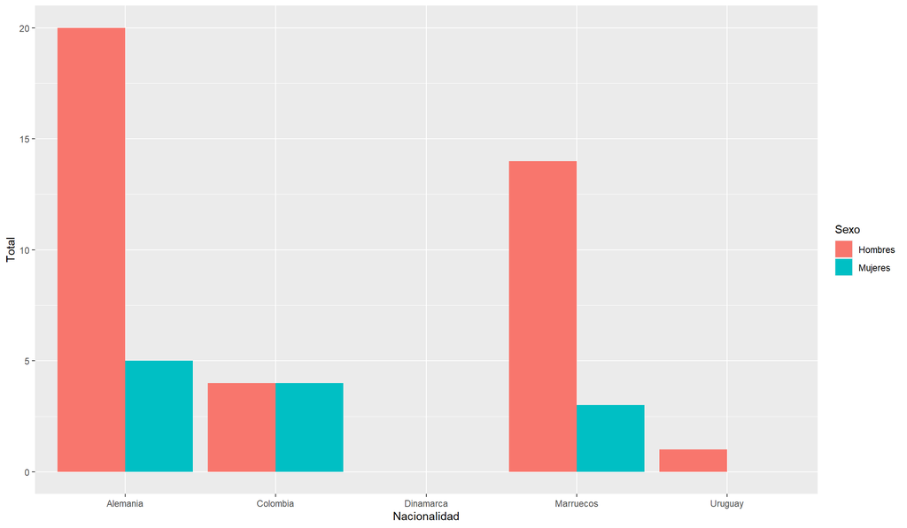

```r
library(ggplot2)
library(readr)
library(tidyverse)

Internacionales_2019 <- read_delim("./INPUT/01002b.csv",
                                   delim = ";", escape_double = FALSE, trim_ws = TRUE)

names (Internacionales_2019) = c("Causas", "Sexo", "Nacionalidad", "Total")

Internacionales_suicidio<-filter(Internacionales_2019, (Causas=="098 Suicidio y lesiones autoinfligidas"))
nacionalidades <- c("Alemania","Marruecos","Colombia","Uruguay","Dinamarca")
df_nacionalidades <- data.frame(nacionalidades)
names(df_nacionalidades) <- c("Nacionalidad")

Internacionales_Nacionalidad_Sexo_f<-
  Internacionales_suicidio %>%
  group_by(Nacionalidad, Sexo)%>%
  filter(., Sexo != "Ambos sexos")%>%
  summarise(across(where(is.numeric), ~ sum(.x, na.rm = TRUE)))

Internacionales_Nacionalidad_Sexo_filtrados <- left_join(df_nacionalidades, Internacionales_Nacionalidad_Sexo_f,
                                                         by = c("Nacionalidad" = "Nacionalidad"))

ggplot(data = Internacionales_Nacionalidad_Sexo_filtrados, aes(x = Nacionalidad, y = Total, fill = Sexo)) +
  geom_col(position = "dodge")
```

Imagen 1. Gráfica de datos correspondiente a los 5 países seleccionados como muestra

#### Estudio datos Castilla y León

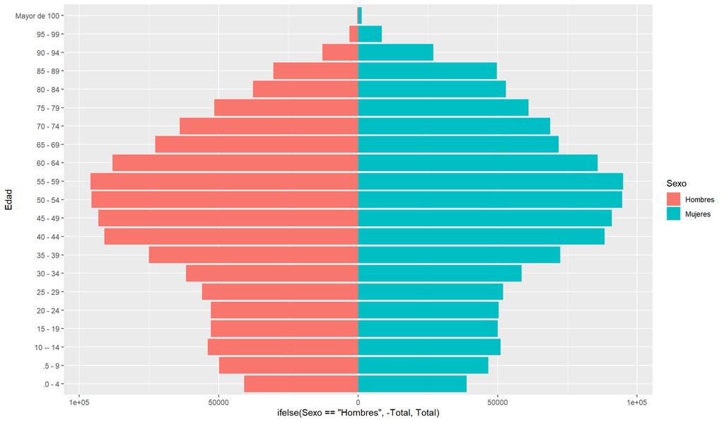

```r
datosPiramide <- read_delim("./Input/poblacion.csv",
  delim = ";", escape_double = FALSE, trim_ws = TRUE)

names (datosPiramide) = c("Comunidad", "Edad", "Sexo", "Periodo", "Total")

ggplot(datosPiramide, aes(x = Edad,fill = Sexo,
                          y = ifelse(Sexo == "Hombres", - Total, Total)))+
  geom_bar(stat = "identity")+
  scale_y_continuous(limits = max(datosPiramide$Total)*c(-1,1),labels = abs)+
  coord_flip()
```

Imagen 2. Gráfica con los datos poblacionales de Castilla y León para su comparación con los de suicidio

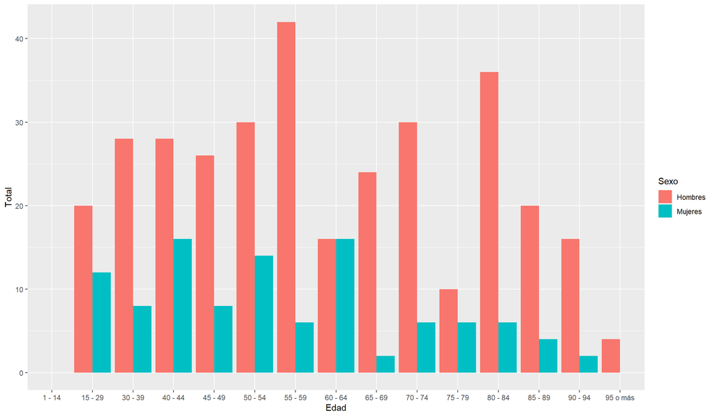

```r
Cyl_2019 <- read_delim("./INPUT/02008.csv",
                                   delim = ";", escape_double = FALSE, trim_ws = TRUE)

names (Cyl_2019) = c("Provincias", "Causas", "Sexo", "Edad", "Total")

Cyl_suicidio<-filter(Cyl_2019, (Causas=="098 Suicidio y lesiones autoinfligidas"))

Cyl_Sexo_Edades<-
  Cyl_suicidio %>%
  group_by(Sexo, Edad)%>%
  summarise(across(where(is.numeric), ~ sum(.x, na.rm = TRUE)))%>%
  filter(., Sexo != "Ambos sexos")%>%
  filter(., Edad != "Todas las edades")%>%
  filter(., Edad != "Menores de 1 año")


Cyl_Sexo_Edades$Edad[ Cyl_Sexo_Edades$Edad == "De 1 a 14 años"] <- "1 - 14"
Cyl_Sexo_Edades$Edad[ Cyl_Sexo_Edades$Edad == "De 15 a 29 años"] <- "15 - 29"
Cyl_Sexo_Edades$Edad[ Cyl_Sexo_Edades$Edad == "De 30 a 39 años"] <- "30 - 39"
Cyl_Sexo_Edades$Edad[ Cyl_Sexo_Edades$Edad == "De 40 a 44 años"] <- "40 - 44"
Cyl_Sexo_Edades$Edad[ Cyl_Sexo_Edades$Edad == "De 45 a 49 años"] <- "45 - 49"
Cyl_Sexo_Edades$Edad[ Cyl_Sexo_Edades$Edad == "De 50 a 54 años"] <- "50 - 54"
Cyl_Sexo_Edades$Edad[ Cyl_Sexo_Edades$Edad == "De 55 a 59 años"] <- "55 - 59"
Cyl_Sexo_Edades$Edad[ Cyl_Sexo_Edades$Edad == "De 60 a 64 años"] <- "60 - 64"
Cyl_Sexo_Edades$Edad[ Cyl_Sexo_Edades$Edad == "De 65 a 69 años"] <- "65 - 69"
Cyl_Sexo_Edades$Edad[ Cyl_Sexo_Edades$Edad == "De 70 a 74 años"] <- "70 - 74"
Cyl_Sexo_Edades$Edad[ Cyl_Sexo_Edades$Edad == "De 75 a 79 años"] <- "75 - 79"
Cyl_Sexo_Edades$Edad[ Cyl_Sexo_Edades$Edad == "De 80 a 84 años"] <- "80 - 84"
Cyl_Sexo_Edades$Edad[ Cyl_Sexo_Edades$Edad == "De 85 a 89 años"] <- "85 - 89"
Cyl_Sexo_Edades$Edad[ Cyl_Sexo_Edades$Edad == "De 90 a 94 años"] <- "90 - 94"
Cyl_Sexo_Edades$Edad[ Cyl_Sexo_Edades$Edad == "De 95 años y más"] <- "95 o más"

ggplot(data = Cyl_Sexo_Edades, aes(x = Edad, y = Total, fill = Sexo)) +
  geom_col(position = "dodge")
```

Imagen 3. Gráfica correspondiente a los datos de suicidio Castilla y León en el año 2019

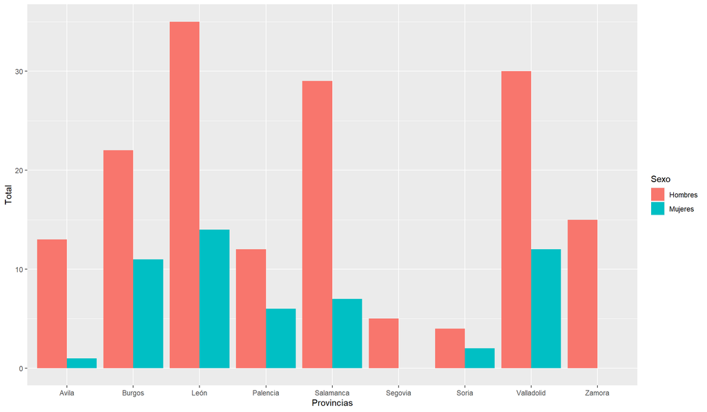

```r
Cyl_provincia<-
  Cyl_suicidio %>%
  group_by(Provincias)%>%
  filter(., Provincias != "Castilla y León")%>%
  filter(., Sexo != "Ambos sexos")

ggplot(data = Cyl_provincia, aes(x = Provincias, y = Total, fill = Sexo)) +
  geom_col(position ='dodge')
```

Imagen 4. Gráfica descriptiva de los datos separados por provincias.

En los datos separados por provincias se observa que no necesariamente aquellas provincias más pobladas son las que tienen mayores tasas de suicidio, observable por ejemplo en la comparación entre Valladolid y León.

#### Estudio datos nacionales

A la hora de trabajar con los datos nacionales hemos tomado la decisión de filtrar los datos posteriores a 2005, dado que los anteriores sospechamos que son una acumulación puesto que son cifras dudosas.

La decisión tomada finalmente es estudiar los datos divididos por sexos en función del año, y estos datos muestran que el suicidio se mantiene como una causa de muerte más presente en la población masculina y en los últimos años aumenta la tasa de suicidios general.

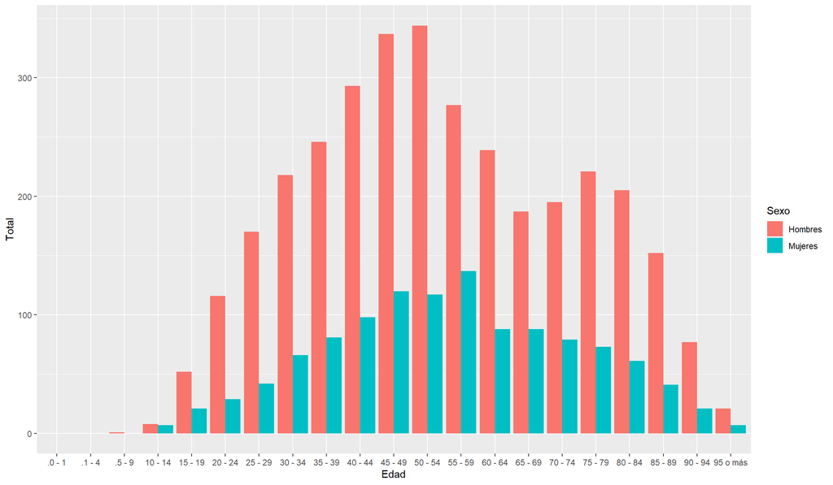

```r
Nacionales_historico <- read_delim("./INPUT/6609.csv",
                      delim = ";", escape_double = FALSE, trim_ws = TRUE)

names (Nacionales_historico) = c("Causas", "Sexo", "Edad", "Periodo", "Total")
Nacionales_historico_filtro<-filter(Nacionales_historico, (Periodo>2005))

Nacionales_suicidio<-filter(Nacionales_historico_filtro, (Causas=="098  Suicidio y lesiones autoinfligidas"))

Nacionales_Sexo_Edades<-
  Nacionales_suicidio %>%
  group_by(Sexo, Edad)%>%
  filter(., Sexo != "Total")%>%
  filter(., Edad != "Todas las edades")%>%
  arrange(., desc(Edad))

Nacionales_Sexo_Edades$Edad[Nacionales_Sexo_Edades$Edad == "Menos de 1 año"] <- ".0 - 1"
Nacionales_Sexo_Edades$Edad[Nacionales_Sexo_Edades$Edad == "De 1 a 4 años"] <- ".1 - 4"
Nacionales_Sexo_Edades$Edad[Nacionales_Sexo_Edades$Edad == "De 5 a 9 años"] <- ".5 - 9"
Nacionales_Sexo_Edades$Edad[Nacionales_Sexo_Edades$Edad == "De 10 a 14 años"] <- "10 - 14"
Nacionales_Sexo_Edades$Edad[Nacionales_Sexo_Edades$Edad == "De 15 a 19 años"] <- "15 - 19"
Nacionales_Sexo_Edades$Edad[Nacionales_Sexo_Edades$Edad == "De 20 a 24 años"] <- "20 - 24"
Nacionales_Sexo_Edades$Edad[Nacionales_Sexo_Edades$Edad == "De 25 a 29 años"] <- "25 - 29"
Nacionales_Sexo_Edades$Edad[Nacionales_Sexo_Edades$Edad == "De 30 a 34 años"] <- "30 - 34"
Nacionales_Sexo_Edades$Edad[Nacionales_Sexo_Edades$Edad == "De 35 a 39 años"] <- "35 - 39"
Nacionales_Sexo_Edades$Edad[Nacionales_Sexo_Edades$Edad == "De 40 a 44 años"] <- "40 - 44"
Nacionales_Sexo_Edades$Edad[Nacionales_Sexo_Edades$Edad == "De 45 a 49 años"] <- "45 - 49"
Nacionales_Sexo_Edades$Edad[Nacionales_Sexo_Edades$Edad == "De 50 a 54 años"] <- "50 - 54"
Nacionales_Sexo_Edades$Edad[Nacionales_Sexo_Edades$Edad == "De 55 a 59 años"] <- "55 - 59"
Nacionales_Sexo_Edades$Edad[Nacionales_Sexo_Edades$Edad == "De 60 a 64 años"] <- "60 - 64"
Nacionales_Sexo_Edades$Edad[Nacionales_Sexo_Edades$Edad == "De 65 a 69 años"] <- "65 - 69"
Nacionales_Sexo_Edades$Edad[Nacionales_Sexo_Edades$Edad == "De 70 a 74 años"] <- "70 - 74"
Nacionales_Sexo_Edades$Edad[Nacionales_Sexo_Edades$Edad == "De 75 a 79 años"] <- "75 - 79"
Nacionales_Sexo_Edades$Edad[Nacionales_Sexo_Edades$Edad == "De 80 a 84 años"] <- "80 - 84"
Nacionales_Sexo_Edades$Edad[Nacionales_Sexo_Edades$Edad == "De 85 a 89 años"] <- "85 - 89"
Nacionales_Sexo_Edades$Edad[Nacionales_Sexo_Edades$Edad == "De 90 a 94 años"] <- "90 - 94"
Nacionales_Sexo_Edades$Edad[Nacionales_Sexo_Edades$Edad == "95 y más años"] <- "95 o más"

ggplot(data = Nacionales_Sexo_Edades, aes(x = Edad, y = Total, fill = Sexo)) +
  geom_col(position = "dodge")
```

Ahora nos centramos en un rango de edad concreto y lo analizamos a lo largo de los años, desde el 2005 al 2020 y comprobamos como a medida que pasan los años el número de suicidios incrementa tanto en hombres como en mujeres.

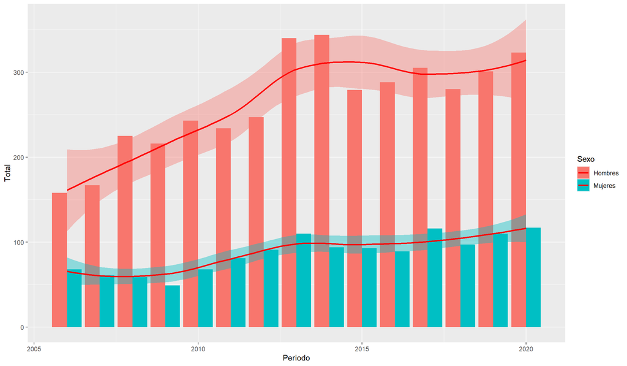

```r
Nacionales_50 <- Nacionales_suicidio%>%
  filter(., Edad == "De 50 a 54 años")%>%
  filter(., Sexo != "Total")
ggplot(data = Nacionales_50, aes(x = Periodo, y = Total, fill = Sexo)) +
geom_col(position = "dodge") + geom_smooth(method = "loess", colour = "red")
```

Imagen 6. Gráfica de análisis del progreso a lo largo del tiempo de la franja de edad entre 50 y 54 años

## Interpretación de los datos

Por último, adjuntamos imágenes que corresponden a noticias actuales que hablan sobre el tema tratado:

[figure not shown]

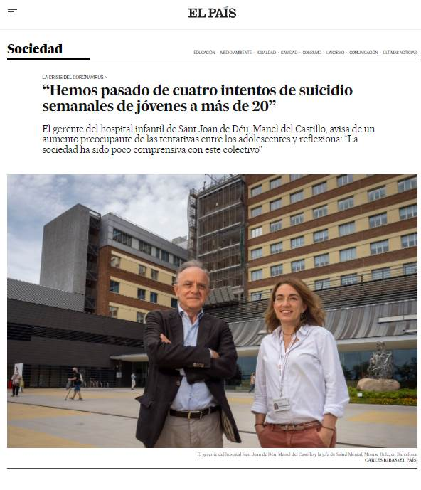

[figure not shown]

Algunos enlaces de interés sobre el tema trabajado y de carácter informativo o de apoyo:

- https://medlineplus.gov/spanish/ency/article/001554.htm.
- https://www.mayoclinic.org/es-es/diseases-conditions/suicide/in-depth/suicide/art-20044707.
- https://www.who.int/es/news-room/fact-sheets/detail/suicide.
- https://childmind.org/es/articulo/suicidio-en-adolescentes-cuales-son-los-factores-de-riesgo/.
- https://telefonodelaesperanza.org/.